[Imtiaj.](https://imtiajiqbalmahfuj.github.io/index.html#top)

# PM2.5 & Dust Mapping: Spatiotemporal Monitoring with MERRA-2

### Spatiotemporal Analysis of Dust Scattering Aerosol Optical Thickness (AOT) over Bangladesh

> *Leveraging Earth Observation data to visualize invisible atmospheric hazards through cloud computing.* 👀

[figure not shown]

> **Author:** Imtiaj Iqbal Mahfuj

## 📝 Overview

This project explores **spatial patterns** of atmospheric aerosols, specifically focusing on **Dust Scattering Aerosol Optical Thickness (AOT)** as a proxy for PM2.5 and dust concentration. By integrating **NASA MERRA-2 datasets** with **Google Earth Engine (GEE)** and Python's geospatial ecosystem, this workflow automates the extraction and visualization of air quality data over Bangladesh.

The primary objective is to bridge the gap between massive satellite archives and actionable insights. Ground-based air quality monitoring stations are often sparse; this project utilizes reanalysis data to reconstruct historical air quality trends. It aims to uncover key insights—such as seasonal dust spikes and regional hotspots—that support data-driven decision-making for environmental researchers and urban planners.

The analysis specifically targets the 2008-2009 timeline to demonstrate the workflow's capability in handling historical time-series data. By converting Earth Engine image collections into multi-dimensional **Xarray** datasets, the project enables high-performance analysis of meteorological variables (DUSCAT25) across both temporal and spatial dimensions.

## 🛠️ Tools & Technologies

## ⚙️ Methodology

| Step | Description |
| --- | --- |
| 1. Data Collection | Acquisition of **NASA/GSFC/MERRA/aer/2** data, specifically the `DUSCAT25` band (Dust Scattering AOT). |
| 2. Preprocessing | Temporal filtering (2008–2009) and spatial clipping to the **Bangladesh** region (AOI) using GEE. |
| 3. Analysis | Daily aggregation of image collections and conversion to `xarray` datasets for multi-dimensional handling. |
| 4. Visualization | Generation of spatiotemporal heatmaps and time-series plots to identify peak dust events. |

# Codes⤵️

## Import Libraries

```python
import ee
import xarray as xr
import xee
import geemap
import matplotlib.pyplot as plt
```

```python
ee.Authenticate()
ee.Initialize()
```

## Collect Datasets

```python
m = geemap.Map()
m.setCenter(90.4125, 23.8103, 6)
m
```

```
Map(center=[23.8103, 90.4125], controls=(WidgetControl(options=['position', 'transparent_bg'], position='topri…
```

[figure not shown]

```python
aoi = m.user_roi

if aoi is None:
    print("⚠️ No region selected! Using the map's current center as a fallback.")
    # Fallback to current map bounds or center
    aoi = ee.Geometry.Rectangle(m.getBounds())

print("Selected AOI:", aoi.getInfo()['type'])
```

```
Selected AOI: Polygon
```

```python
# AOI = (ee.FeatureCollection("FAO/GAUL/2015/level2")
#        .filter(ee.Filter.eq('ADM2_NAME', 'Dhaka')).geometry())
```

```python
col = (ee.ImageCollection("NASA/GSFC/MERRA/aer/2")
       .select("DUSCAT25"))
```

```python
time_start = ee.Date("2008")
time_end = ee.Date("2009")
time_dif = time_end.difference(time_start, "days")
time_list = (ee.List.sequence(0, ee.Number(time_dif).subtract(1))
             .map(lambda interval: time_start.advance(interval, "days")))
```

```python
def daily_agg(date):
    start_date = ee.Date(date)
    end_date = start_date.advance(1, 'days')
    image = col.filterDate(start_date, end_date).mean()
    return image.set("system:time_start", start_date.millis())
```

```python
col_daily = ee.ImageCollection(time_list.map(daily_agg))
```

```python
ds = xr.open_dataset(col_daily, engine = "ee", crs = "EPSG:4326", scale= 0.5, geometry=aoi)
```

```python
ds
```

```
<xarray.Dataset> Size: 196kB
Dimensions:   (time: 366, lon: 11, lat: 12)
Coordinates:
  * time      (time) datetime64[ns] 3kB 2008-01-01 2008-01-02 ... 2008-12-31
  * lon       (lon) float64 88B 87.77 88.27 88.77 89.27 ... 91.77 92.27 92.77
  * lat       (lat) float64 96B 20.82 21.32 21.82 22.32 ... 25.32 25.82 26.32
Data variables:
    DUSCAT25  (time, lon, lat) float32 193kB ...
Attributes:
    crs:      EPSG:4326
```

## Plotting

```python
timeseries_data = ds['DUSCAT25'].mean(dim=['lat', 'lon']).compute()
```

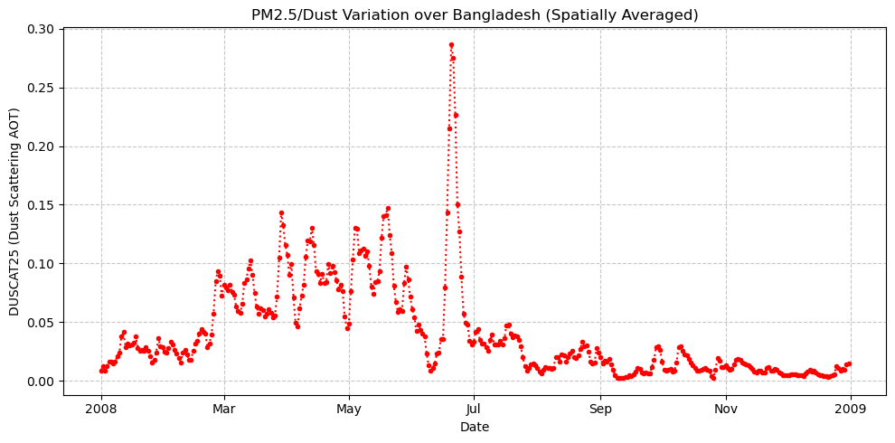

```python
fig, ax = plt.subplots(figsize=(10, 5))
timeseries_data.plot(ax=ax, marker='o', linestyle=':', markersize=3, color='red')

ax.set_xlabel('Date')
ax.set_ylabel('DUSCAT25 (Dust Scattering AOT)')
ax.set_title('PM2.5/Dust Variation over Bangladesh (Spatially Averaged)')
plt.grid(True, linestyle='--', alpha=0.7)
plt.tight_layout()
plt.savefig('BD_pm25.png', dpi=300)
plt.show()
```

```python
# 1. Compute the mean (Average over time)
ds_mean = ds['DUSCAT25'].mean(dim='time').compute()

# 2. Check if we have enough data for a map (Grid vs. Single Point)
plt.figure(figsize=(10, 6))

if ds_mean.ndim >= 2 and ds_mean.size > 1:
    # --- CASE A: Large Area (Map) ---
    ds_mean.plot(cmap='coolwarm', robust=True)
    plt.title(f"Spatial Distribution of Dust (Mean)")

    # Save the map directly
    plt.savefig("map_spatial.png", dpi=300, bbox_inches='tight')
    print("✅ Success! Spatial map saved as 'map_spatial.png'")

else:
    # --- CASE B: Single Point/Small City (Time Series) ---
    print("⚠️ Area is too small for a spatial map (1 pixel). Saving Time Series graph instead.")

    # Get the time series for this point
    ts_data = ds['DUSCAT25'].mean(dim=['lat', 'lon']).compute()

    # Plot the line graph
    ts_data.plot(marker='o', linestyle='-', color='red', markersize=3)
    plt.title("Dust Variation (Single Location)")
    plt.xlabel("Date")
    plt.ylabel("DUSCAT25")
    plt.grid(True)

    # Save the graph directly
    plt.savefig("map_timeseries.png", dpi=300, bbox_inches='tight')
    print("✅ Success! Time series graph saved as 'map_timeseries.png'")

plt.close() # Closes the plot to free up memory
```

```
✅ Success! Spatial map saved as 'map_spatial.png'
```

## 📊 Results & Insights

- 🔹 **Seasonal Volatility:** The time-series analysis reveals a distinct, sharp rise in dust scattering AOT during the pre-monsoon season (specifically around June 2008), indicating high particulate matter loading.
- 🔹 **Spatial Distribution:** The spatial mean map highlights variations in dust intensity across different coordinates of Bangladesh, identifying regions with consistently higher AOT values.
- 🔹 **Data Interoperability:** Successfully demonstrated the seamless transition of data from Google Earth Engine's cloud infrastructure to local Python `xarray` structures for granular analysis.

[figure not shown]

*Caption: Dust Scattering AOT (DUSCAT25) over Bangladesh (2008-2009).*

## ❓ Why this project?

- **Addressing Data Scarcity:** In regions like Bangladesh, continuous historical ground data for PM2.5 is often missing. This project fills that gap using reanalysis data.
- **Scalability:** The workflow is designed to be location-agnostic; it can be easily adapted to monitor dust or other air quality parameters (CO, NO2, SO2) for any region in the world.
- **Impact:** vital for climate resilience planning, helping authorities understand long-term trends in atmospheric pollution.

## ✨ Features

- **Cloud-Native Processing:** Heavylifting is done on Google Earth Engine servers.
- **Automated Visualization:** Script automatically determines whether to plot a spatial map or a time-series graph based on the AOI size.
- **Exportable Analytics:** Generates high-resolution PNGs (`BD_pm25.png`, `map_spatial.png`) ready for reports.
- **Notebook-ready:** Fully compatible with Jupyter and Google Colab environments.

## 📎 Links

- 🔗 [See more in LinkedIn](https://www.linkedin.com/in/imtiajiqbalmahfuj/)

## 🔖 Tags

`GIS` `Remote Sensing` `Geospatial Python` `Python` `GEE` `Spatial Data-Science` `Air Quality` `NASA MERRA-2` `Xarray`

## 📌 Credits & Shoutouts

- 👨‍💻 **Author:** [Imtiaj Iqbal Mahfuj](https://imtiajiqbalmahfuj.github.io/)
- 🙌 **Inspiration:** Special thanks to the **Open Source Geospatial Community** and **Amirhossein Ahrari** (creator of xee) for the tools that make this analysis possible.
- 🗂️ **Data Sources:** NASA Goddard Space Flight Center (MERRA-2 Data).

## 💬 Connect with Me

📧 Email: imtiajiqbal.ruet@gmail.com 🌐 Portfolio: https://imtiajiqbalmahfuj.github.io/